# Guía de trabajo variables discretas

Diplomado en Análisis de datos con R para la acuicultura

Dr. José A. Gallardo y Dra. María Angélica Rueda.

Pontificia Universidad Católica de Valparaíso  
jose.gallardo@pucv.cl

02 July 2021

```r
knitr::opts_chunk$set(echo = TRUE)

# Librería stats está instalada por defecto en la base de R
library(stats)

# Librería pander permite crear tablas con leyendas en Rmarkdown
library(pander)

# Librería MASS contiene funciones de apoyo para trabajar con el libro de Venables and Ripley llamado Modern Applied Statistics with S (2002)
library(MASS)

# Librería Rlab permite cargar las funciones para la distribución Bernoulli.
library(Rlab)
```

#### **Clasificación de variables**

**Variables discretas:** Una variable **Y** es *discreta* si puede tomar valores puntales (enteros positivos incluyendo el cero), puede tener un número finito o infinito de valores. Todas las probabilidades asociadas a cada valor de la variable aleatoria discreta deberán sumar 1. La función de distribución de probabilidad acumulada es, la probabilidad de que la variable aleatoria sea menor o igual a un valor particular.

**Tipos de distribución de variables discretas**

Hay diferentes tipos de distribuciones acordes a variables cuantitativas discretas, en este caso solo veremos dos, estás son: la distribucción *Bernoulli* **(Be)** y la *distribución Binomial* **(B)**.

La **distribución bernoulli** aplica a un caso especial de variable discreta cuando solo hay dos niveles. Estos niveles usalmente representan la ocurrencia de un evento (exito) o su ausencia (fracaso) y se representan con los números 1 y 0 respectivamente.

Ejemplo variables con distribución bernoulli: vivo frente a un desafío a un patógeno (0), muerto (1); positivo a un patógeno (1) o negativo (0).

Ejemplo de variable con distribución binomial: Abundancia de parásitos en un pez.

#### **Distribución de una variable discreta**

*Distribución empírica (observación)*: Los datos de una muestra, obtenidos de forma aleatoria de una población, pueden ser usados para observar su distribución.

*Distribución de probabilidad (predicción)*: Las variables aleatorias tienen diferente distribución de probabilidad asociada, es decir, ésta dependerá de la naturaleza de la variable aleatoria en estudio. Considerando esto, es posible predecir su comportamiento y realizar inferencias estadísticas.

#### **Objetivos de aprendizaje**

Los objetivos de aprendizaje de esta guía son:

**1**. Observar y predecir el comportamiento de variables aleatorias discretas con distribución Bernoulli.

**2**. Observar y predecir el comportamiento de variables aleatorias discretas con distribución de Binomial.

**3**. Elaborar un reporte html con **[Rmarkdown](https://rmarkdown.rstudio.com/)**.

#### **Comandos**

A continuación, se presentan algunos comandos que podrían ser usados para resolver los ejercicios de esta guía. Otros, los usará más adelante en el curso y los deberá investigar por su propia cuenta.

*¿Cómo puedo observar el comportamiento de una variable discreta?*

**1.-** Tabla de distribución de frecuencia **table()**.

**2.-** Gráfico de barras **barplot()**.

**3.-** Histograma **hist()**.

*¿Cómo puedo predecir el comportamiento de una variable con distribución Bernoulli?*

**4.-** Mediante la *función de distribución de probabilidad acumulada* **pbern()**.

**5.-** Mediante *la función de densidad de probabilidad Bernoulli* **dbern()**.

**6.-** Mediante la función para encontrar los *cuantiles* **qbern()**.

*¿Cómo puedo predecir el comportamiento de una variable con distribución Binomial?*

**7.-** Mediante la *función de distribución de probabilidad acumulada* **pbinom()**.

**8.-** Mediante la *función de densidad de probabilidad Binomial* **dbinom()**.

**9.-** Mediante la función para encontrar los *cuantiles* **qbinom()**.

*¿Cómo puedo simular números aleatorios con distribución Binomial y Bernoulli?*

**10.-** Simular variable aleatoria Bernoulli **rbern()**

**11.-** Simular variable aleatoria Binomial **rbinom()**

### **Ejercicio 1.** Elaborar archivo Rmarkdown

Elabore un archivo o file con extensión .Rmd y configurelo para exportar el resultado como un documento dinámico pdf. Utilice el siguiente ejemplo para completar la información de metadatos: Título: Reporte EDA, nombre del autor: Su nombre.

Luego guarde inmediatamente su script como script_4_nombre_apellido.Rmd. Al finalizar la actividad deberá exportar y almacenar este script en su carpeta drive de tareas.

Ejercicio 2. Configuración del reporte En el primer bloque de códigos o chunk configure los comandos de la siguiente manera:

{r setup, include=TRUE, warning=FALSE,message=FALSE}

knitr::opts_chunk$set(echo = TRUE)

Cargue las librerías stats, Rlab, MASS y pander usando la función library().

Ejercicio 3. Borrar información de la plantilla Borre los bloques de códigos R que se generan automáticamente con cada archivo .Rmd y reemplacelos por nuevos bloques de códigos con el botón verde +C que se encuentra en la parte superior del panel de códigos.

Ejecute cada uno de los siguientes ejercicios en uno o más bloques de códigos diferentes. Sea ordenado y documente su reporte adecuadamente. Para la exportación de salmón se implementa un sistema de inspección visual del producto, clasificando a los peces como defectuosos **(D)** y no defectuosos **(ND)**.

**a.** ¿Que tipo de variable y distribución mejor representará el número de salmones defectuosos?

```r
# Variable Discreta
# Distribución Binomial
```

**b.** Si en un proceso de inspección se detectó un total de 8 salmones defectuosos y 24 no defectuosos. ¿Cuál es la probabilidad de que los salmones sean defectuosos?

```r
p <- 8 / 32
```

**c.** ¿Cuál es la probabilidad de que no sean defectuosos?

```r
q <- 1-p
```

**d** El comprador del salmón desea checar que la información de origen de la proporción de salmón defectuosa es correcta. Para ello deside tomar una muestra aleatoria de solo 3 salmones.

Responda las siguientes preguntas usando la información de la siguiente tabla relacionada al ejercicio 1:

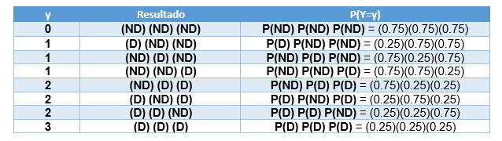

**e.** ¿Cuál es la probabilidad de que el comprador no detecte salmones defectuosos?

```r
# P(Y=0)
P_ND <- q*q*q
```

**f.** ¿Cuál es la probabilidad de que detecte que todos son salmones defectuoso?

```r
# P(Y=3)
P_PD <- p*p*p
```

### **Ejercicio 2.**

La abundancia de parásitos como el piojo de mar *Caligus rogercresseyi* en los salmones de cultivo en Chile puede ser considerada como una variable distreta con distribución binomial negativa. Esto significa que uno suele observar muchos peces con pocos parásitos (ej= 0 o 1) y pocos peces con muchos parásitos. Un estudio demostró que el promedio de la abundancia de parásitos fue de 25 con un rango de 0 a 100.

A partir de estos datos realice una simulación del número de parásitos como se indica a continuación.

**a.** Cree un objeto llamado **caligus** para representar el número de parásitos en los peces. Simule una muestra aletoria con distribución binomial negativa con la función **rnegbin()**. Considere 1000 peces con una media de 25 parásitos. Para simular la varianza debe asignar valores arbitrarios al argumento **theta** entre 1 y 5 hasta obtener un promedio y rango aproximado al estudio antes descrito. Para evitar que la simulación genere un resultado diferente cada vez, incluya en la primera línea de codigo el siguiente comando **set.seed(123)**.

```r
set.seed(123)
# n = 1000 animales
# mu = 25 (parásitos por pez)
# theta = 1 (cambie este valor hasta encontrar uno que se ajuste a los datos observados en el ejercicio)
caligus <- rnegbin (1000, 25, 3)
```

**b.** Use las funciones **head()** y **range()** para observar sus datos. Compare las funciones **quantile()** y **summary()**.

```r
head(caligus)
```

```
## [1] 17 42  3 24 50 25
```

```r
range(caligus)
```

```
## [1]  0 98
```

```r
quantile(caligus)
```

```
##   0%  25%  50%  75% 100%
##    0   13   21   31   98
```

```r
summary(caligus)
```

```
##    Min. 1st Qu.  Median    Mean 3rd Qu.    Max.
##    0.00   13.00   21.00   23.74   31.00   98.00
```

**c.** ¿Que parámetro representa mejor los datos, la mediana o la media?

```r
# La mediana representa mejor los datos puesto que la media es muy influenciable por los valores extremos.
```

**d.** A partir de la simulación anterior elabore un histograma y una gráfica de cajas y bigotes. Use la función **par(mfrow=c(1,2))** para generar las gráficas en una sola fila y con 2 columnas.

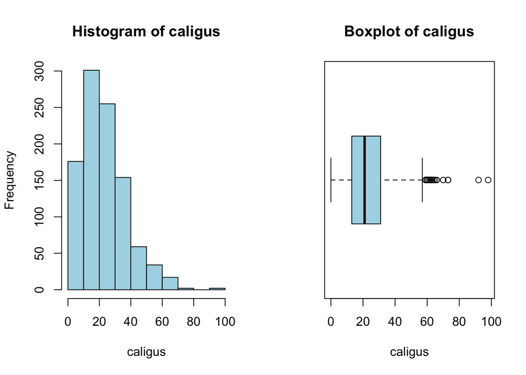

```r
par(mfrow=c(1,2))
hist(caligus, col="lightblue")
boxplot(caligus, col="lightblue", main="Boxplot of caligus", horizontal = TRUE, xlab="caligus")
```

**e.** A partir de la simulación de parásitos y usando la función **plot()** elabore una gráfica con la distribución acumulada empírica. Debe incluir la función **ecdf()**.

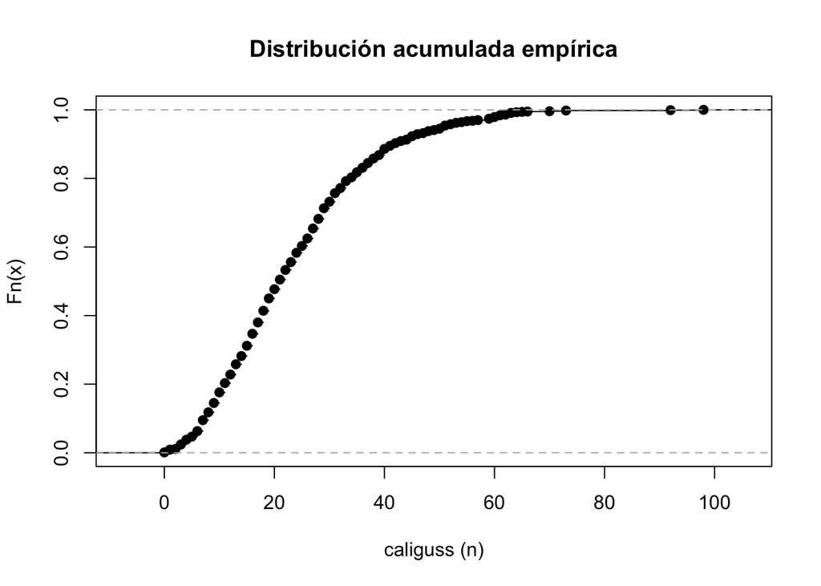

```r
# Distribución acumulada empírica.
plot(ecdf(caligus), main="Distribución acumulada empírica", xlab="caliguss (n)")
```

**f.** A partir de la simulación de parásitos y usando la función **plot()** elabore elabore una gráfica con la densidad empírica. Debe incluir la función **density()**.

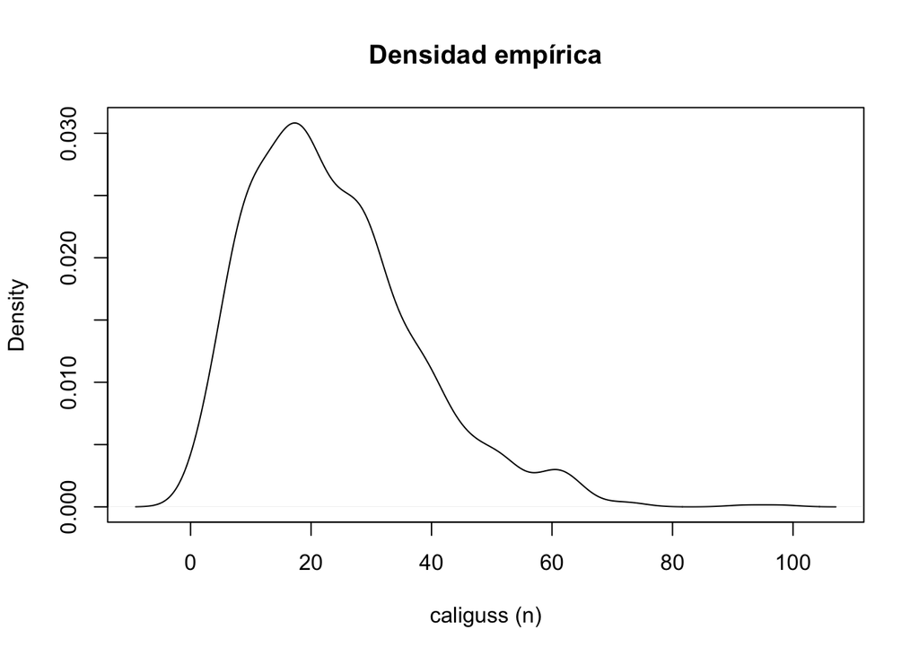

```r
# Densidad empírica.
plot(density(caligus), main="Densidad empírica", xlab="caliguss (n)")
```

**g.** En una sola gráfica combine un histograma hist() y una función de densidad de los datos simulados use **lines(density())**.

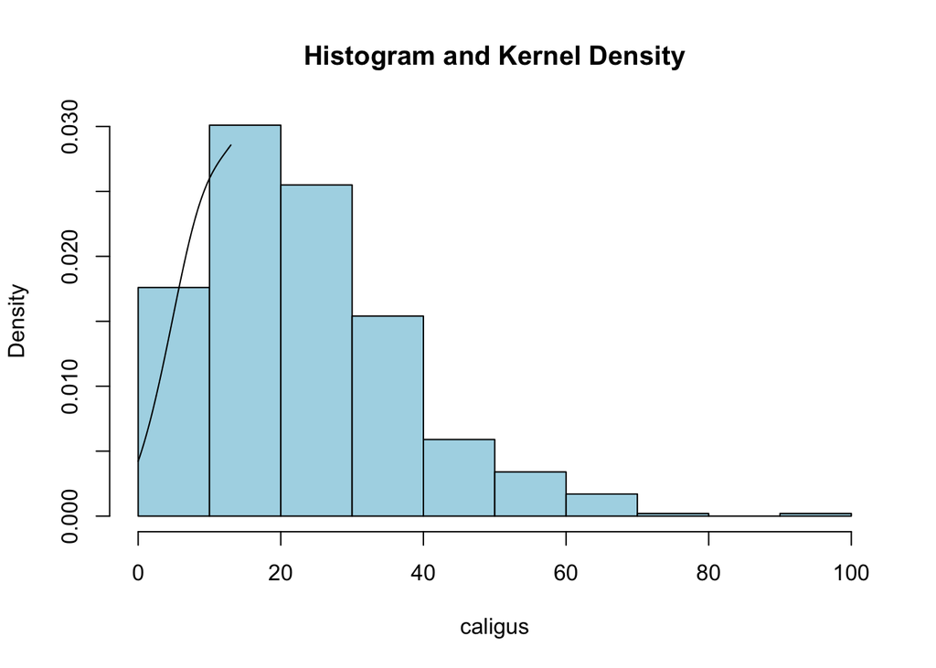

```r
hist(caligus, probability = TRUE, col="lightblue", main = "Histogram and Kernel Density")
lines(density(caligus, from = 0, to = 13))
```

### **Ejercicio 3.**

*Alexandrium catenella* es una microalga tóxica que produce el veneno paralizante de los mariscos (VPM). En Chile las intoxicaciones por VPM entre 1972-2002 generaron 456 enfermos y 30 fallecidos (total = 486). A partir de estos antecedentes responda.

**a.** ¿Cuál es la letalidad por VPM en Chile?

```r
30 / 486
```

```
## [1] 0.0617284
```

**b.** ¿Que tipo de variable y distribución mejor representa a la intoxicación por VPM?

```r
# "Variable Discreta"
# "Distribución Bernoulli"
```

**c.** Se ha reportado un intoxicación masiva de veneno paralizante de los mariscos en Calbuco que dió como resultado 80 personas intoxicadas. ¿Cuántas personas se recuperarán (0) y cuantas morirán (1) por esta intoxicación?.

Para responder primero cree un objeto denominado **rvpm** y simule el resultado de la intoxicación usando **rbinom()**. Use **print()** para observar sus datos simulados.

```r
set.seed(123)
n <- 80
p <- 0.0617
q <- 1-p
rvpm<-rbinom(n, size=1, prob=0.0617)
print(rvpm)
```

```
##  [1] 0 0 0 0 1 0 0 0 0 0 1 0 0 0 0 0 0 0 0 1 0 0 0 1 0 0 0 0 0 0 1 0 0 0 0 0 0 0
## [39] 0 0 0 0 0 0 0 0 0 0 0 0 0 0 0 0 0 0 0 0 0 0 0 0 0 0 0 0 0 0 0 0 0 0 0 0 0 0
## [77] 0 0 0 0
```

**d.** Represente en una tabla la frecuencia esperada de recuperados y fallecidos

```r
table(rvpm)
```

```
## rvpm
##  0  1
## 75  5
```

```r
#Tabla con formato para reporte

knitr::kable(
  table(rvpm),
  row.names = TRUE
  , caption = "Recuperados (0) versus fallecidos (1)")
```

Recuperados (0) versus fallecidos (1)

|  | rvpm | Freq |
| --- | --- | --- |
| 1 | 0 | 75 |
| 2 | 1 | 5 |

**d.** represente en un histograma la frecuencia de recuperados y fallecidos

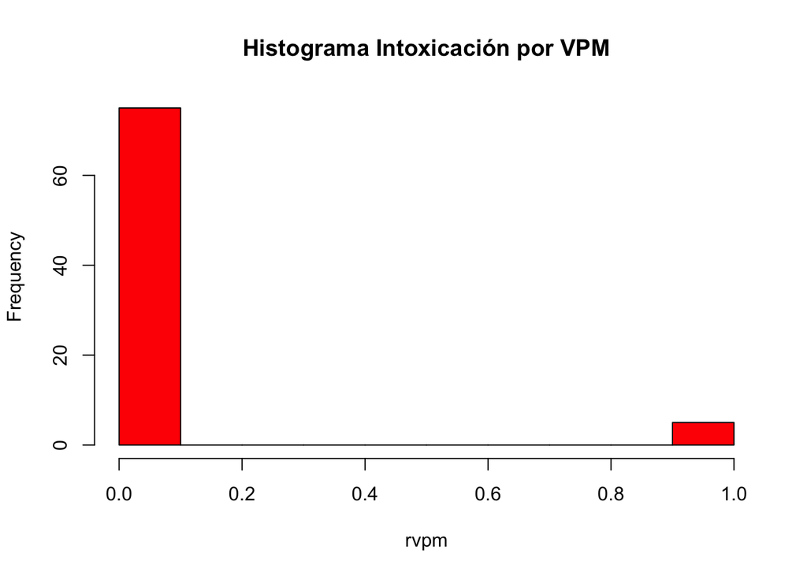

```r
hist(rvpm, col="red", main = "Histograma Intoxicación por VPM")
```

**e.** Investigue como se calcula el promedio y la varianza de una variable con distribución binomial. Calcule ambos parámetros para la población de estudio.

Promedio de fallecidos

```r
n*p
```

```
## [1] 4.936
```

Varianza de fallecidos

```r
n*p*q
```

```
## [1] 4.631449
```

**f.** Gráfique función de densidad de las intoxicaciones por VPM usando una la función plot. En el eje “x” grafique los datos simulados con rbinom() y en el eje “y” la función de densidad dbinom().

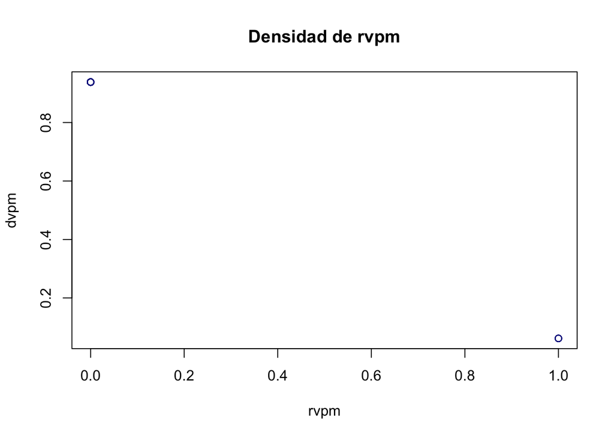

```r
dvpm<-dbinom(rvpm, size=1, prob=0.0617)
plot(x=rvpm, y=dvpm, main="Densidad de rvpm", col="blue4")
```

**g.** Gráfique la distribución de probabilidad acumulada de las intoxicaciones por VPM usando la función plot(). En el eje “x” grafique los datos simulados con rbinom() y en el eje “y” la probabilidad acumulada con pbinom().

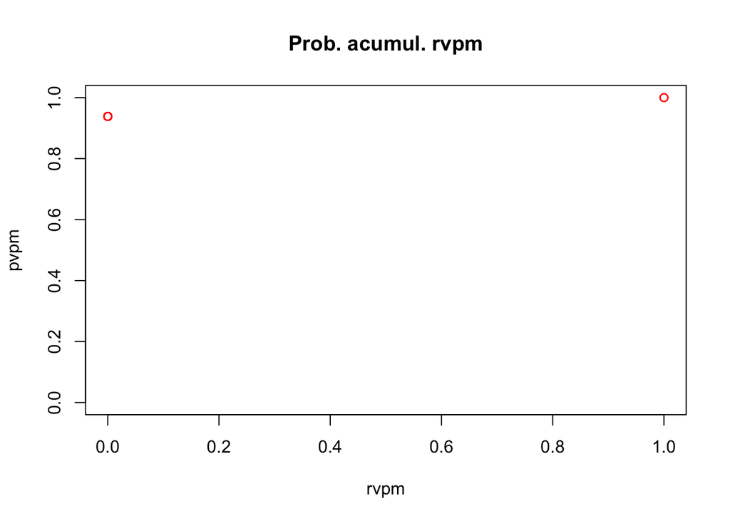

```r
pvpm<-pbinom(rvpm, size=1, prob=0.0617)
plot(x=rvpm, y=pvpm, main="Prob. acumul. rvpm", col="red", ylim=c(0,1))
```